# Projet Semestriel : Mathématiques pour le Big Data

| Nom | Prénom |
| --- | --- |
| CAI | Eddy |
| MBAE | Hakim |
| SHEIKH | Rakib |
| TARANTO | Tom |

#### Exercice 1 : Cas d’une matrice non diagonalisable

Soit la matrice

$$\mathbf{A} = \left[\begin{array}
{rrr}
0 & 2 & 2 \\
-1 & 2 & 2 \\
-1 & 1 & 3
\end{array}\right]$$
**1. Ecrire une fonction qui calcule les valeurs propres ainsi que leur multiplicité d’une matrice carrée quelconque. Appliquer sur $A$**

Version précédente :

```r
library(limSolve)
library(expm)
#Q1
A= matrix(c(0,2,2,-1,2,2,-1,1,3), nrow = 3, byrow = T)
q1<-function(A){
  valeurs<-Re(eigen(A)$values)
  print(valeurs)
  res<-table(valeurs)
  print(res)
  return(res)
}

A
```

```
##      [,1] [,2] [,3]
## [1,]    0    2    2
## [2,]   -1    2    2
## [3,]   -1    1    3
```

```r
res<-as.matrix(q1(A))
```

```
## [1] 2 2 1
## valeurs
## 1 2
## 1 2
```

```r
res
```

```
##   [,1]
## 1    1
## 2    2
```

```r
dim(res)
```

```
## [1] 2 1
```

```r
eigen(A)$values
```

```
## [1] 2+0i 2-0i 1+0i
```

**2. Donner les vecteurs propres de A pour chaque valeur propre. Pourquoi A n’est pas diagonalisable ? Justifier.**

```r
vec_propre<-Re(eigen(A)$vectors)
vec_propre
```

```
##           [,1]      [,2]          [,3]
## [1,] 0.8164966 0.8164966  8.944272e-01
## [2,] 0.4082483 0.4082483 -4.213000e-16
## [3,] 0.4082483 0.4082483  4.472136e-01
```

**3. Donner la matrice de Jordan $J$ de $A$ ainsi qu’une matrice de passage $P$ permettant d’effectuer le changement de base entre $A$ et $J$ . Calculer $P-1$ et vérifier le changement de base**

```r
#Q3
#On réarrange les vecteurs propres pour les mettre dans le bon ordre
vec_propre<-vec_propre[,c(3,1,2)]

I3<-diag(1,nrow = 3)


#Pour trouver une base du sous-espace propre associé à lambda = 2,
#On cherche un antécédent du vecteur propre associé à lambda=2 par A-2*I3
new_vect<-Solve(A-2*I3, vec_propre[,2])

#On remplace ce nouveau vecteur dans la matrice de passage
vec_propre[,3]<-new_vect



P<-vec_propre
#La matrice de Jordan est composée des blocs de Jordan

#retourne le bloc de Jordan correspondant à vp l de multiplicité m
jordan_block<-function(l,m){
  if( m == 1) return(l)
  else{
    res<-matrix(rep(0,m*m), nrow = m)
    for (i in c(1:m)) {
      res[i,i]<-l
    }
    for (i in c(1:(m-1))) {
      res[i,i+1]<-1
    }
    return(res)
    }

}

#Retourne la matrice de Jordan associée aux valeurs propres
jordan_matrix<-function(val, multi){
  n<-sum(multi)
  res<-matrix(rep(0,n*n), nrow = n)
  idx<-1
  for (i in c(1:length(multi))) {
    jb<-jordan_block(val[i], multi[i])
    res[idx:(idx+multi[i]-1),idx:(idx+multi[i]-1)]<-jb
    idx<-idx + multi[i]
  }
  return(res)
}

#Valeurs propres : 1, 2. Multiplicité de 1:1 , multiplicité de 2 : 2
J<-jordan_matrix(c(1,2),c(1,2))
print("J")
```

```
## [1] "J"
```

```r
J
```

```
##      [,1] [,2] [,3]
## [1,]    1    0    0
## [2,]    0    2    1
## [3,]    0    0    2
```

```r
print("P")
```

```
## [1] "P"
```

```r
P
```

```
##               [,1]      [,2]       [,3]
## [1,]  8.944272e-01 0.8164966 -0.1360828
## [2,] -4.213000e-16 0.4082483  0.1360828
## [3,]  4.472136e-01 0.4082483  0.1360828
```

```r
#On vérifie que l'on tombe bien sur A

q <- P%*%J%*%solve(P, tol = NULL)
print("Verifions que PJP-1 = A")
```

```
## [1] "Verifions que PJP-1 = A"
```

```r
q
```

```
##               [,1] [,2] [,3]
## [1,] -1.332268e-15    2    2
## [2,] -1.000000e+00    2    2
## [3,] -1.000000e+00    1    3
```

```r
A
```

```
##      [,1] [,2] [,3]
## [1,]    0    2    2
## [2,]   -1    2    2
## [3,]   -1    1    3
```

```r
#On réarrange les vecteurs propres pour les mettre dans le bon ordre
vec_propre<-vec_propre[,c(3,1,2)]
vec_propre
```

```
##            [,1]          [,2]      [,3]
## [1,] -0.1360828  8.944272e-01 0.8164966
## [2,]  0.1360828 -4.213000e-16 0.4082483
## [3,]  0.1360828  4.472136e-01 0.4082483
```

```r
I3<-diag(1,nrow = 3)


#Pour trouver une base du sous-espace propre associé à lambda = 2,
#On cherche un antécédent du vecteur propre associé à lambda=2 par A-2*I3
new_vect<-Solve(A-2*I3, vec_propre[,2])
new_vect
```

```
## [1] -0.1490712  0.3726780 -0.0745356
```

```r
#On remplace ce nouveau vecteur dans la matrice de passage
vec_propre[,3]<-new_vect
vec_propre
```

```
##            [,1]          [,2]       [,3]
## [1,] -0.1360828  8.944272e-01 -0.1490712
## [2,]  0.1360828 -4.213000e-16  0.3726780
## [3,]  0.1360828  4.472136e-01 -0.0745356
```

```r
P<-vec_propre
#La matrice de Jordan est composée des blocs de Jordan
J<-jordan <-matrix(c(1,0,0,0,2,1,0,0,2), nrow = 3, byrow = T)
J
```

```
##      [,1] [,2] [,3]
## [1,]    1    0    0
## [2,]    0    2    1
## [3,]    0    0    2
```

```r
P
```

```
##            [,1]          [,2]       [,3]
## [1,] -0.1360828  8.944272e-01 -0.1490712
## [2,]  0.1360828 -4.213000e-16  0.3726780
## [3,]  0.1360828  4.472136e-01 -0.0745356
```

```r
#On vérifie que l'on tombe bien sur A
P%*%J%*%solve(P)
```

```
##           [,1] [,2]       [,3]
## [1,] 2.4666667  2.4 -0.9333333
## [2,] 0.3333333  2.0 -0.6666667
## [3,] 0.7333333  1.2  0.5333333
```

```r
A
```

```
##      [,1] [,2] [,3]
## [1,]    0    2    2
## [2,]   -1    2    2
## [3,]   -1    1    3
```

**4. On pose**

$$\begin{cases} a_{n+1} = 2b_n +2c_n \\ b_{n+1} = -a_n + 2b_n + 2c_n & \mbox{avec } a_0 = 1, b_0 = 2, c_0 =-3 \\ c_{n+1} = -a_n + b_n + 3c_n \end{cases}$$
**En utilisant $J^{25}$, $P$ et $P^{-1}$, écrire une fonction qui retourne $a_25$, $b_25$ , $c_25$**

```r
#Q4

library(expm)
# Fonction calculant les n-ieme termes de la suite a_n
abc<-function(J,P,N){
  X0<-c(1,2,-3)
  JN<-J%^%N
  res<-P %*% JN %*% solve(P) %*% X0
  return(res)

}
X0<-c(1,2,-3)
abc(J,P,25)
```

```
##            [,1]
## [1,] 4317336920
## [2,]  145402536
## [3,] 2158668456
```

#### **Exercice 2 : Interpolation de données**

**Soit un nuage de points 2D : $\Delta = \{(x_i , y_i), i = 0, ..., n\}$ . On suppose que^ $x_0 < x_1 < ... < x_n$ sont des entiers relatifs triés et $y_0, y_1 , ..., y_n$ des entiers relatifs quelconques**

**On souhaite interpoler $\Delta$ par un polynôme de degré inférieure ou égal à $n$.**

**1. Créer une fonction qui génère graphiquement $\Delta$ aléatoirement tel que l’utilisateur saisisse le nombre de points et $a, b, c, d$ pour que $\forall i = 0, ..., n, a \leq x_i \leq b, c \leq y_i \leq d$ . Proposer un exemple.**

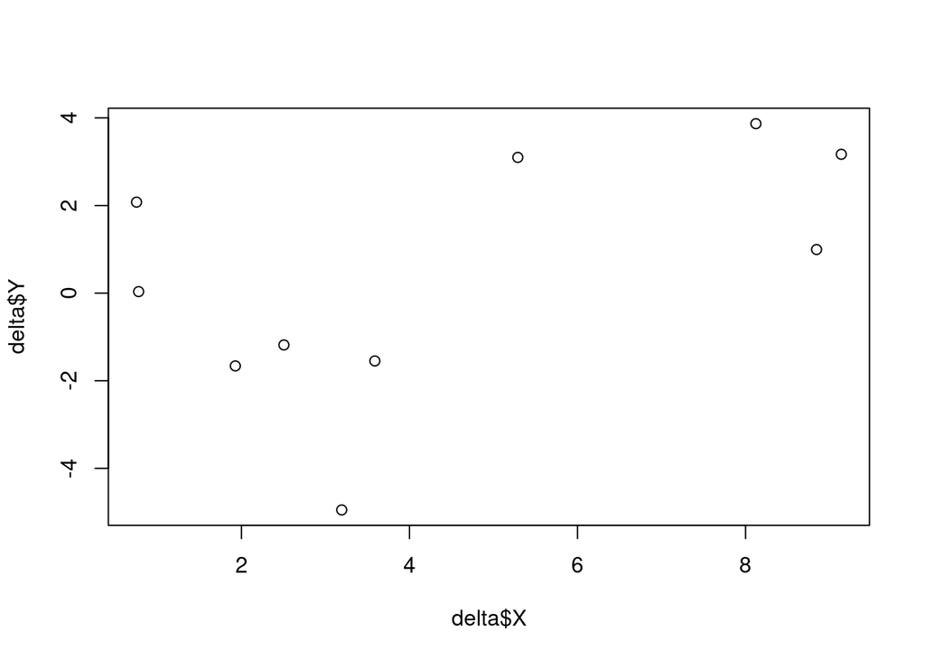

```r
library(polynom)

options(digits=10)

#Question 1

#Fonction de génération de delta
generate <- function(N,a,b,c,d){
  #Wichmann-Hill generator to reduce the number of duplicates
  RNGkind("Wich")
  #Xi
  X<-sort(runif(n = N, min = a, max = b))
  #Yi
  Y<-runif(n = N, min = c, max = d)
  L<-list("X" = X, "Y" = Y)
  return(L)
}

#On génère les X entre 0 et 10 et les y entre -5 et 5 avec 10 valeurs
delta<-generate(10,0,10,-5,5)
#On affiche le résultat graphiquement
plot(delta$X, delta$Y)
```

**2. Donner la matrice de vandermonde permettant un première interpolation polynomiale de $\Delta$ , avec $n = 9$, puis $n = 19$ et enfin $n = 29$. Que constate-t-on ? Retourner et tracer si possible le polynôme d’interpolation.**

```r
#Retourne la matrice de Vandermonde pour les Xi données
vandermonde <- function(xi){
  N<-length(xi)
  #On créé la matrice contenant les xi
  res<-matrix(rep(xi,N),ncol = N)
  #On les met a la bonne puissance
  res<-res^(col(res)-1)
  return(res)
}

#Matrice de vandermonde pour nos données
vdm<-vandermonde(delta$X)
vdm
```

```
##       [,1]         [,2]          [,3]           [,4]            [,5]
##  [1,]    1 0.7514240568  0.5646381132   0.4242826617    0.3188161989
##  [2,]    1 0.7763211750  0.6026745668   0.4678690279    0.3632166335
##  [3,]    1 1.9272072846  3.7141279177   7.1578943787   13.7947461889
##  [4,]    1 2.5053816440  6.2769371822  15.7261231968   39.3999403888
##  [5,]    1 3.1933408599 10.1974258476  32.5638566249  103.9874939164
##  [6,]    1 3.5875130657 12.8702499964  46.1721900204  165.6433349688
##  [7,]    1 5.2894231599 27.9779973645 147.9874672278  782.7683365306
##  [8,]    1 8.1227600932 65.9792315313 535.9334688612 4353.2589934637
##  [9,]    1 8.8448092830 78.2306512521 691.9351904076 6120.0347953314
## [10,]    1 9.1392030642 83.5250326481 763.3522343126 6976.4310788701
##                  [,6]            [,7]            [,8]            [,9]
##  [1,] 2.395661615e-01 1.800157770e-01 1.352681854e-01 1.016437687e-01
##  [2,] 2.819727637e-01 2.189014272e-01 1.699378132e-01 1.319263228e-01
##  [3,] 2.658533534e+01 5.123545194e+01 9.874133620e+01 1.902950224e+02
```

[output cut: 18 more lines]

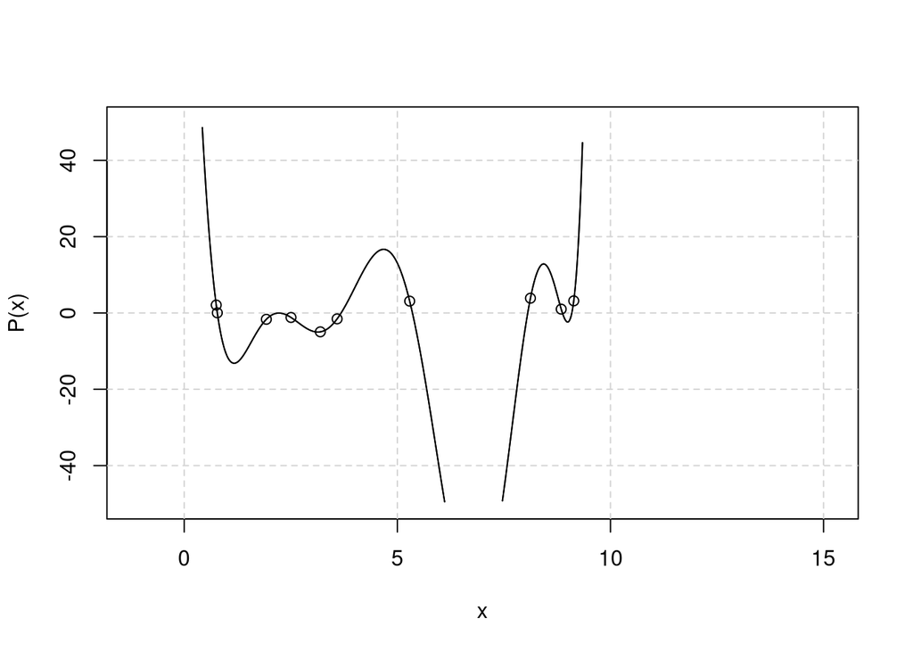

```r
#Fonction retournant les coefficients du polynôme d'interpolation grâce a Vandermonde
coef_vdm<-function(d){

  #mat[mat < 0.1] <- NA
  #print(vandermonde(d$X))
  coeff<- solve(round(vandermonde(d$X), digits = 8),matrix(d$Y, ncol=1), tol = NULL)
  return(coeff)
}

coef<-coef_vdm(delta)

p = as.polynomial(coef)

#Avec le détail
plot(p, ylim = c(-50,50), xlim = c(-1,15))
points(delta$X, delta$Y)
```

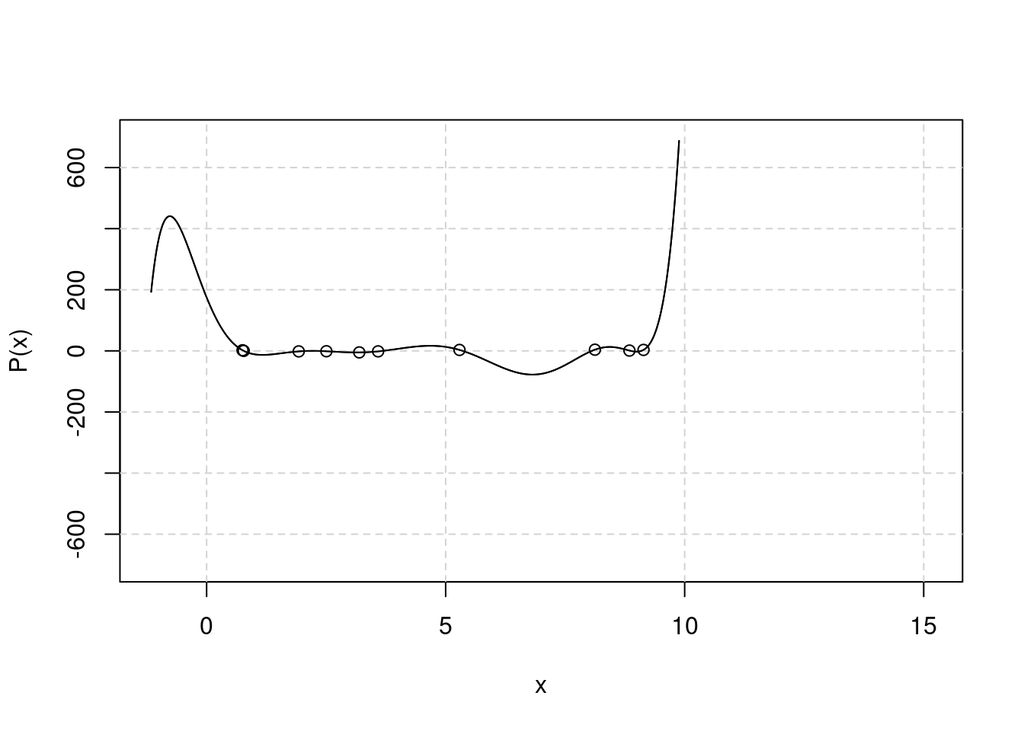

```r
#Avec la courbe s'affichant sur le dernier point
plot(p, ylim = c(-700,700), xlim = c(-1,15))
points(delta$X, delta$Y)
```

```r
print(p)
```

```
## 175.0294667 - 385.3219739*x + 175.7760458*x^2 + 127.499053*x^3 -
## 157.8053411*x^4 + 66.56116057*x^5 - 14.54568169*x^6 + 1.751274148*x^7 -
## 0.1100654432*x^8 + 0.002821055686*x^9
```

```
## 77094.7669 - 183585.5495*x + 167846.7037*x^2 - 80403.54395*x^3 +
## 22568.94455*x^4 - 3849.805508*x^5 + 392.7499101*x^6 - 22.01650673*x^7 +
## 0.5209055469*x^8
```

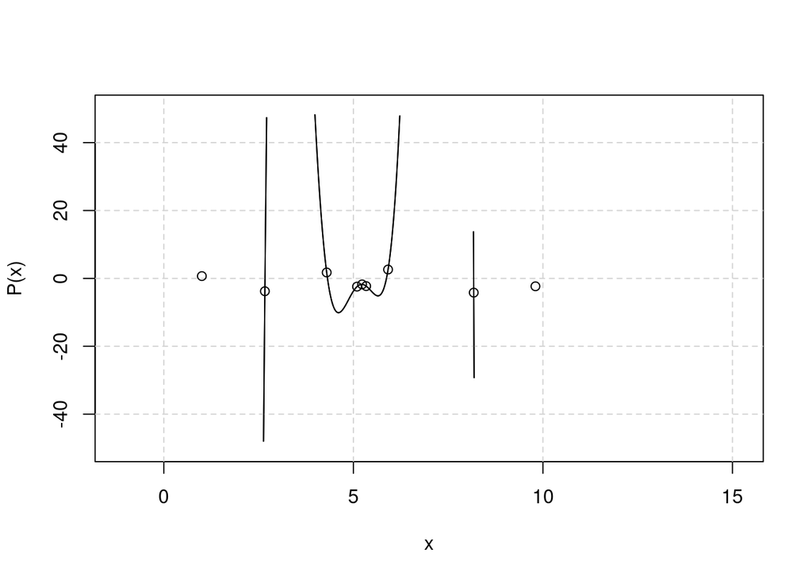

```r
ex_deux_q_deux<-function(N){
  delta<-generate(N,0,10,-5,5)
  vdm<-vandermonde(delta$X)
  p<-as.polynomial(coef_vdm(delta))
  print(p)
  plot(p, ylim = c(-50,50), xlim = c(-1,15))
  points(delta$X, delta$Y)
}

ex_deux_q_deux(9)
```

```r
ex_deux_q_deux(19)
```

```
## 3916358.445 - 30541004.8*x + 100019008.5*x^2 - 183404315.7*x^3 +
## 213005257.2*x^4 - 168749063.7*x^5 + 95791822.75*x^6 - 40293309.1*x^7 +
## 12849084.38*x^8 - 3152802.654*x^9 + 600269.1767*x^10 - 88905.60635*x^11 +
## 10209.04151*x^12 - 899.6476252*x^13 + 59.67521545*x^14 - 2.882164608*x^15 +
## 0.09564899872*x^16 - 0.001949989545*x^17 + 1.840968692e-05*x^18
```

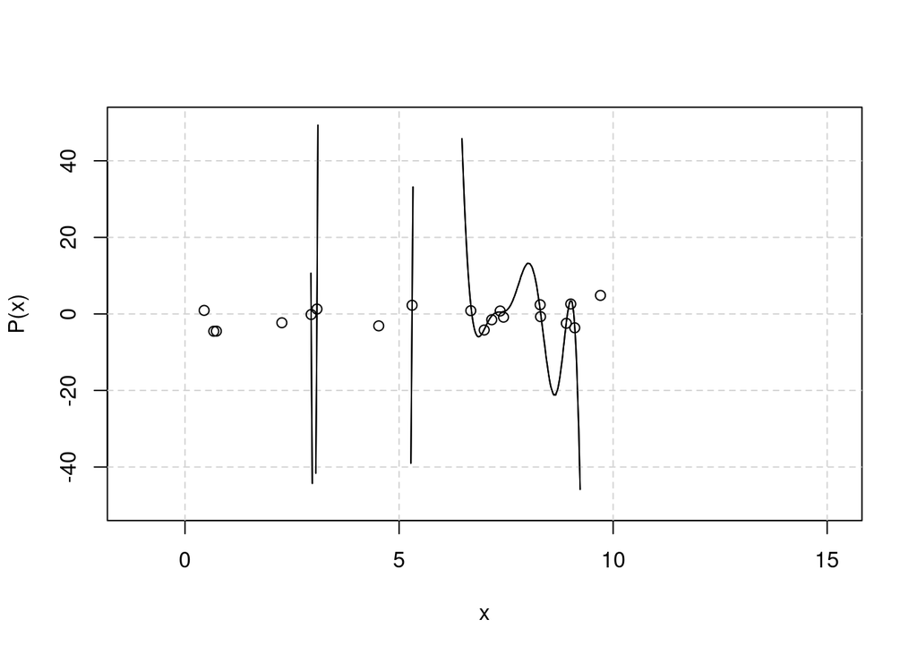

```r
ex_deux_q_deux(29)
```

```
## 153352383.8 - 324455628.9*x - 288643640.3*x^2 + 1934112778*x^3 - 3451492611*x^4
## + 3644661766*x^5 - 2647394143*x^6 + 1405659477*x^7 - 561197049.1*x^8 +
## 170082451*x^9 - 38837176.1*x^10 + 6463486.891*x^11 - 710410.2176*x^12 +
## 32272.46042*x^13 + 4144.202104*x^14 - 902.7863297*x^15 + 63.81034838*x^16 +
## 0.65531859*x^17 - 0.3787615308*x^18 + 0.002947805815*x^19 + 0.004121067047*x^20
## - 0.0003341632464*x^21 - 2.883568547e-05*x^22 + 1.002512824e-05*x^23 -
## 1.294466078e-06*x^24 + 1.017837704e-07*x^25 - 5.033260185e-09*x^26 +
## 1.441674435e-10*x^27 - 1.829334464e-12*x^28
```

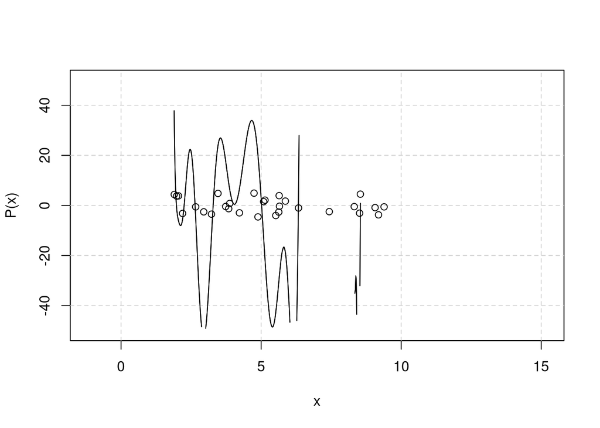

```r
#Pour N=19 ou N=29, l'inversion de la matrice de vandermonde n'est plus possible, la précision de la machine n'est pas assez grande.
#Une erreur de calcul est alors sortie
```

**3. Donner la matrice de Newton permettant une seconde interpolation polynomiale de $\Delta$ , avec $n = 9$, puis $n = 19$ et enfin $n = 29$. Comparer avec la méthode précédente. Retourner et tracer si possible le polynôme d’interpolation**

```
## [1] 2.498513902 3.769840794 3.914814685 7.583277364 8.426717548
## [1]  1.9808043131 -2.3479013711  0.2212181692 -3.1131904441 -3.5382423291
## [1] 4
## 528.6658936 - 475.5956392*x + 147.6458169*x^2 - 18.76722015*x^3 +
## 0.8371327963*x^4
```

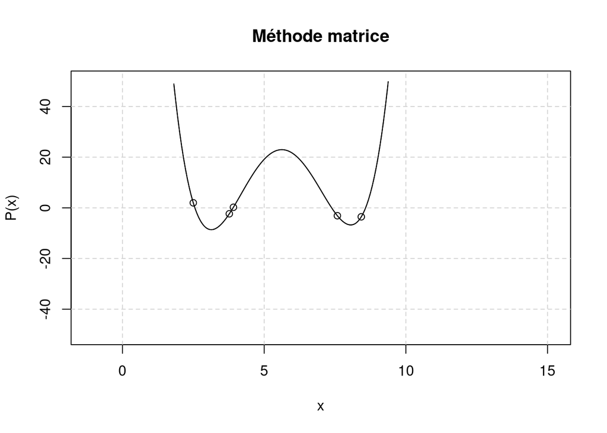

```r
#Fonction et création de la matrice de Newton

newton<-function(xi){
  N<-length(xi)
  res<-matrix(rep(1,N*N),ncol = N)
  #print(res)
  #On parcourt les colonnes
  for (k in (2:N)) {
    #On parcourt les lignes
    for (j in (1:N)){
      #cat(sprintf("%f %f \n", k,j))
      res[j,k] <- res[j,k-1] * (xi[j] - xi[k-1])
      #print(res)

    }
  }
  return(res)
}

#Fonction retournant les coefficients du polynôme d'interpolation grâce a la matrice de Newton
coef_newton<-function(d){

  #Il faut changer cette fonction, ça ne fonctionne pas comme ça
  #coeff<- solve(newton(d$X),matrix(d$Y, ncol=1))
  coeff<-solve(newton(d$X), tol = NULL)%*% d$Y
  return(coeff)
}

#Fonction retournant le polynôme d'interpolation grâce aux coefficients
polynome_newton_from_coef<-function(x,coefs){
  #a<-poly_newt_coef(x,y)
  a<-coefs
  n<-length(x)-1
  print(n)
  p = a[n+1]
  #print(p)
  for (k in c(1:n)){
    p = a[n-k+1] + (polynomial(coef = c(0,1)) - x[n-k+1]) * p
  }
  return(p)
}

#Fonction question 3 exo 2
ex_deux_q_trois<-function(N){
  delta<-generate(N,0,10,-5,5)
  print(delta$X)
  print(delta$Y)
  #Affichage de la matrice de Newton
  newton(delta$X)
  #Calcul des coefs grâce a la matrice
  coefficients1<-coef_newton(delta)
  #Calcul du polynôme
  p1<-polynome_newton_from_coef(delta$X, coefs = coefficients1)
  print(p1)
  plot(p1, ylim = c(-50,50), xlim = c(-1,15), main = "Méthode matrice")
  points(delta$X, delta$Y)
}
ex_deux_q_trois(5)
```

> La première calcule la matrice de Newton > > La deuxième calcule les coefficients du polynôme dans la base de Newton > > La troisième calcule les coefficients du polynôme dans la base canonique de $R[X]$ > >On remarque que la matrice de Newton est triangulaire, on peut l’inverser très facilement avec le pivot de Gauss. Le calcul est donc plus rapide qu’avec la méthode de Vandermonde. En revanche, il faut projeter le polynôme obtenu dans la base canonique de $R[X]$

**4. Toujours, pour l’interpolation de Newton, implémenter le tableau des différences divisées afin de calculer et tracer le polynôme d’interpolation.**

```
## [1] 8
## [1] -1.15893569462 11.84659573016 -8.57621845425  3.03508614551 -0.64274140189
## [6] -0.10224910224  0.16317774235 -0.06993189407  0.01476744140
## 6.718295967 - 90.62026293*x + 292.2579693*x^2 - 325.8338762*x^3 +
## 168.7107085*x^4 - 45.70508006*x^5 + 6.677227964*x^6 - 0.4972517148*x^7 +
## 0.0147674414*x^8
```

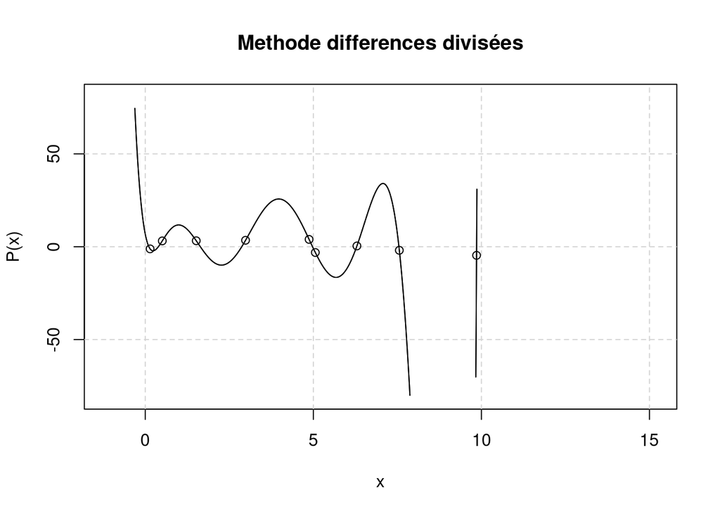

```r
#Fonction de calcul des différences divisées
diff_div_coef<-function(x,y){
  m <-length(x)
  res<-y
  for (k in c(2:m)) {
    res[k:m]<-(res[k:m] - res[k-1])/(x[k:m] - x[k-1])
  }
  return(res)
}

#Fonction question 4 exo 2
ex_deux_q_quatre<-function(N){
  delta<-generate(N,0,10,-5,5)

  #Cette fois-ci on calcule les coefficients grâce aux différences divisées
  coefficients2<-diff_div_coef(delta$X,delta$Y)
  #On calcule le polynô me associé
  p2<-polynome_newton_from_coef(delta$X, coefficients2)
  print(coefficients2)
  print(p2)
  plot(p2, ylim = c(-N*N, N*N), xlim = c(-1,15), main = "Methode differences divisées")
  points(delta$X, delta$Y)
}
ex_deux_q_quatre(9)
```

```r
ex_deux_q_quatre(19)
```

```
## [1] 18
##  [1]   2.783526646254   3.319980311655  -1.251970201745  -2.607028506332
##  [5]  13.433656701887 -76.485598321972 107.998747296514 -69.303553677495
##  [9]  31.281806918998  -8.749461750914   2.377400090428  -0.629547516132
## [13]   0.160608561565  -0.054865243000   0.033986628656  -0.028901683292
## [17]   0.018126228104  -0.007304696483   0.002853975486
## 871421230.1 - 7996502833*x + 24863071650*x^2 - 40740414390*x^3 +
## 42038772110*x^4 - 29964664510*x^5 + 15578765620*x^6 - 6112341959*x^7 +
## 1849389059*x^8 - 437220541.7*x^9 + 81300322.25*x^10 - 11901169.19*x^11 +
## 1364841.433*x^12 - 121215.3226*x^13 + 8168.084679*x^14 - 403.5595675*x^15 +
## 13.78412508*x^16 - 0.2907793535*x^17 + 0.002853975486*x^18
```

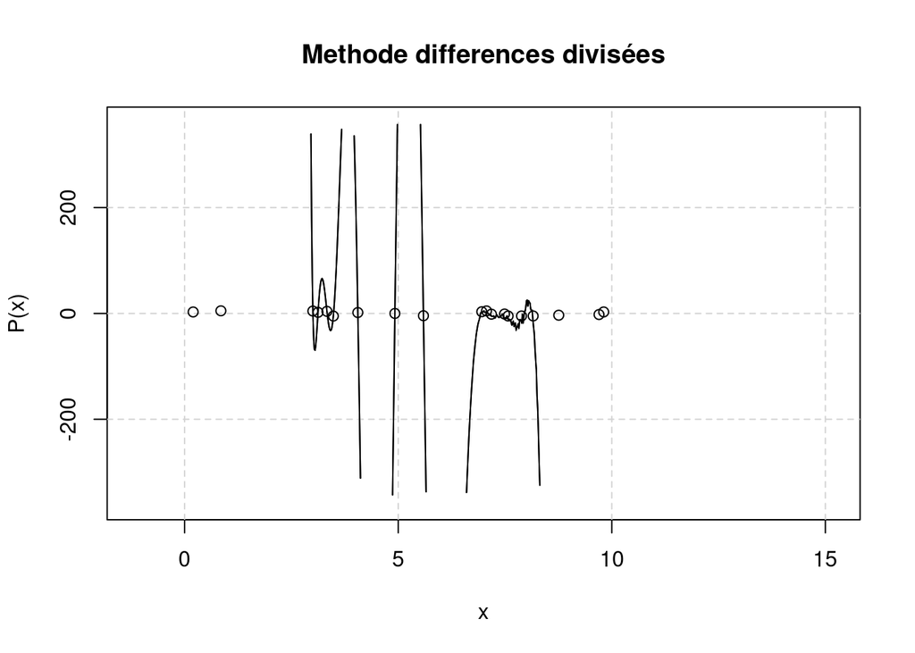

```r
ex_deux_q_quatre(29)
```

```
## [1] 28
##  [1] -3.213962484e+00  2.186441821e+01 -2.087188729e+01 -1.550334717e+00
##  [5]  1.029830266e+01 -3.080621785e+01  1.151269212e+02 -2.941235283e+02
##  [9]  4.538022848e+02 -4.806866924e+02  3.310364174e+02 -1.740944386e+02
## [13]  7.650488329e+01 -2.850952023e+01  8.123079154e+00 -1.932197626e+00
## [17]  4.278109503e-01 -8.711749609e-02  1.556802932e-02 -2.486596923e-03
## [21] -4.029424703e-03  1.030401820e-02 -9.811160432e-03  9.068868571e-03
## [25] -4.673347027e-03  2.374380781e-03 -9.625863641e-04  3.417072393e-04
## [29] -8.792429772e-05
## -24170197890 + 492977756600*x - 3970180630000*x^2 + 17639493770000*x^3 -
## 50326551930000*x^4 + 100661286500000*x^5 - 1.49352396e+14*x^6 +
## 170871913700000*x^7 - 154979858500000*x^8 + 113732751900000*x^9 -
## 68570217940000*x^10 + 34357794230000*x^11 - 14431152900000*x^12 +
## 5113323525000*x^13 - 1535066700000*x^14 + 391490577900*x^15 - 84905722220*x^16
## + 15650809240*x^17 - 2446585491*x^18 + 323028952.7*x^19 - 35798174.16*x^20 +
## 3299940.429*x^21 - 249850.4637*x^22 + 15263.34395*x^23 - 733.324827*x^24 +
## 26.66338823*x^25 - 0.6893190566*x^26 + 0.01128571402*x^27 - 8.792429772e-05*x^28
```

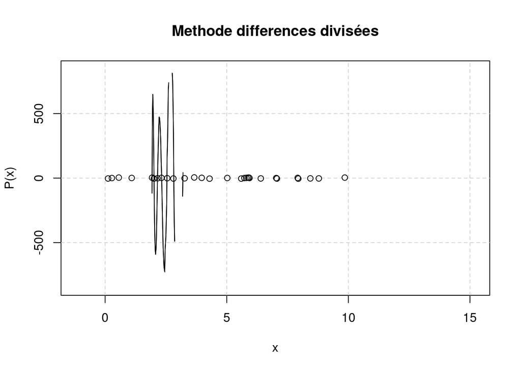

**5. Appliquer les fonctions des questions 2, 3 et 4 à**

```r
ex_deux_q_cinq<-function(){
  delta$X<-c(0,1,2,3,4,5,6,7,8,9)
  delta$Y<-c(2,6,12,20,30,42,56,72,90,110)
  #Polynôme question 2
  vdm<-vandermonde(delta$X)
  p1<-as.polynomial(coef_vdm(delta))

  #Polynôme question 3
  coefficients1<-coef_newton(delta)
  p2<-polynome_newton_from_coef(delta$X, coefs = coefficients1)

  #Polynôme question 4
  coefficients2<-diff_div_coef(delta$X,delta$Y)
  #On calcule le polynome associé
  p3<-polynome_newton_from_coef(delta$X, coefs = coefficients2)


  print("Vandermonde : Y = ")
  print(p1)
  print("Matrice de Newton : Y = ")
  print(p2)
  print("Différences divisées : Y = ")
  print(p3)

  for (new_val in c(5,10,15)) {
    cat("Vandermonde : X = ", new_val, " P(X) = ", predict(p1,new_val),"\n")
    cat("Matrice de Newton : X = ", new_val, " P(X) = ", predict(p2,new_val),"\n")
    cat("Différences divisées : X = ", new_val, " P(X) = ", predict(p3,new_val), "\n")
  }

}
ex_deux_q_cinq()
```

```
## [1] 9
## [1] 9
## [1] "Vandermonde : Y = "
## 2 + 3*x + x^2 + 6.399008307e-14*x^3 - 4.179249539e-14*x^4 + 1.517058084e-14*x^5
## - 3.212245284e-15*x^6 + 3.940410608e-16*x^7 - 2.590520391e-17*x^8 +
## 7.049035077e-19*x^9
## [1] "Matrice de Newton : Y = "
## 2 + 3*x + x^2 - 5.985026876e-13*x^3 + 3.930098193e-13*x^4 - 1.411586522e-13*x^5
## + 2.777521654e-14*x^6 - 3.044752914e-15*x^7 + 1.740264954e-16*x^8 -
## 4.011548038e-18*x^9
## [1] "Différences divisées : Y = "
## 2 + 3*x + x^2
## Vandermonde : X =  5  P(X) =  42
## Matrice de Newton : X =  5  P(X) =  42
## Différences divisées : X =  5  P(X) =  42
## Vandermonde : X =  10  P(X) =  132
## Matrice de Newton : X =  10  P(X) =  132
## Différences divisées : X =  10  P(X) =  132
## Vandermonde : X =  15  P(X) =  272
## Matrice de Newton : X =  15  P(X) =  272
## Différences divisées : X =  15  P(X) =  272
```

**#### Exercice 3 : Approximation de données ####**

**1. Créer une fonction qui génère graphiquement $\Delta$ aléatoirement tel que l’utilisateur saisisse le nombre de points, l’incertitude $\epsilon$ et $a, b, c, d$ pour que $\forall i = 0, ..., n, a \leq x_i \leq b, c \leq y_i \leq d$ . Proposer plusieurs exemple avec $\epsilon = 0.03 , \epsilon = 0.5 , \epsilon = 1 et \epsilon = 5$**

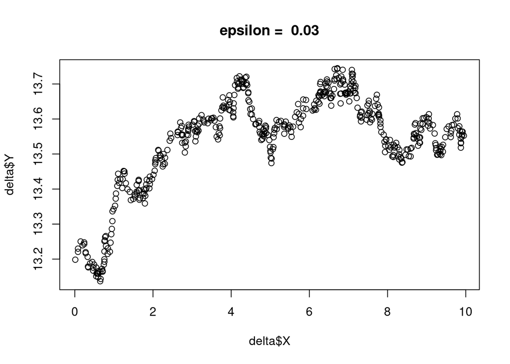

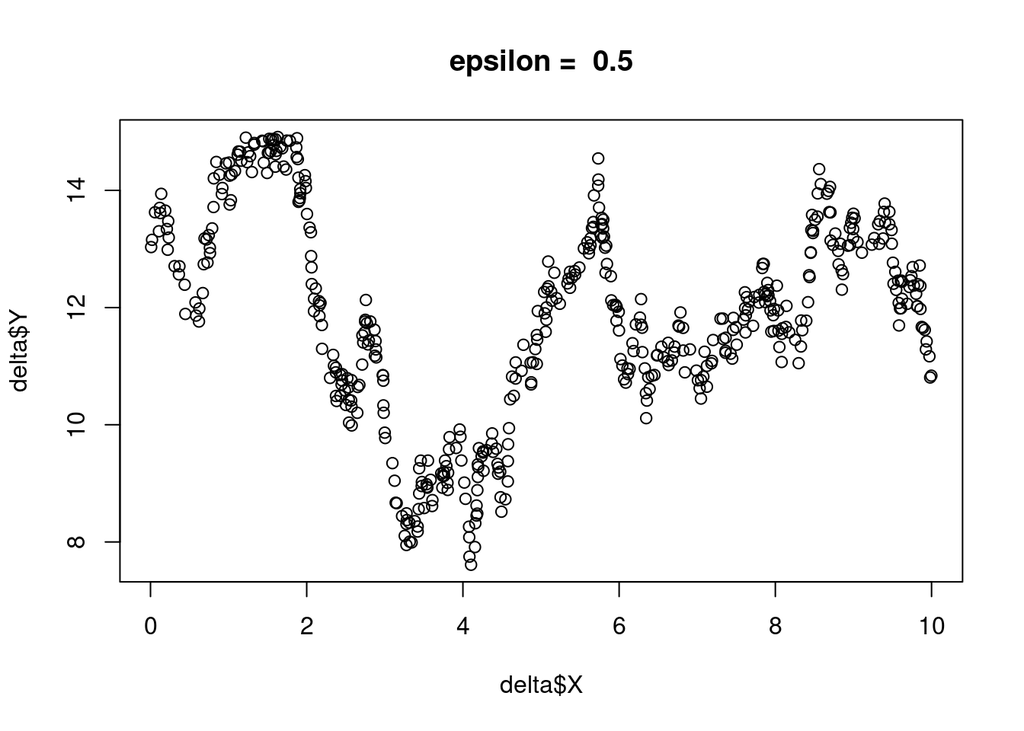

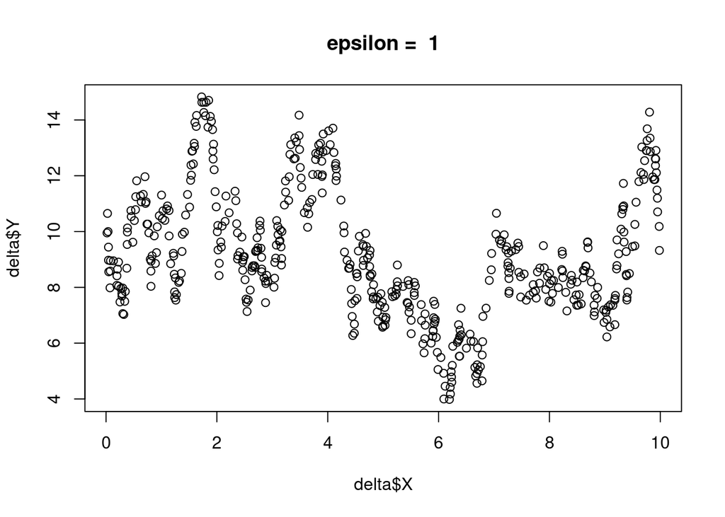

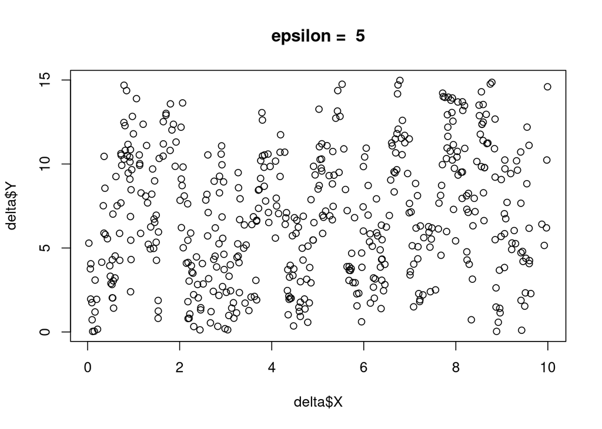

```r
generate<-function(N,e,a,b,c,d){

  RNGkind("Wich")
  #Xi
  X<-sort(runif(n = N, min = a, max = b))
  #Yi
  Y<-rep(c,N)
  Y[1]<-runif(1,c,d)
  for (i in c(2:N)) {
    Y[i]<-runif(1,min = max(Y[i-1] - e,c), max = min(Y[i-1] + e, d))
  }

  L<-list("X" = X, "Y" = Y)
  return(L)
}

q1<-function(){
for (e in c(0.03,0.5,1,5)) {
  delta<-generate(500,e,0,10,0,15)
  plot(delta$X,delta$Y, main = paste("epsilon = ",e))

  }
}
q1()
```

**2. Comment choisir le degré du polynôme d’interpolation de $\Delta$ ? Donner un critère de choix et écrire la fonction.**

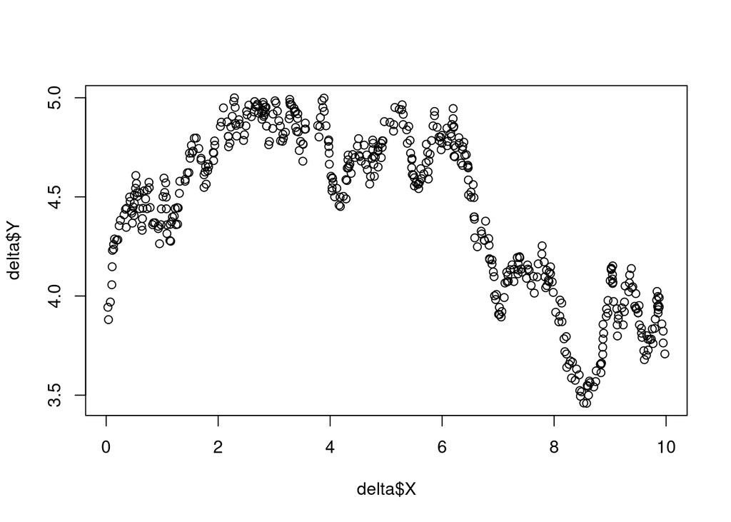

```r
q2<-function(){

  delta<-generate(500,0.1,0,10,0,5)
  plot(delta$X,delta$Y)

  # degre<-readline(prompt = "Combien de pics voyez vous?")

 # return((as.integer(degre)+1))


}
q2()
```

**3. Déterminer le polynôme d’approximation par la méthode des moindres carrés. Effectuer le tracé.**

```
## 0.5369142034 + 0.02670885693*x
```

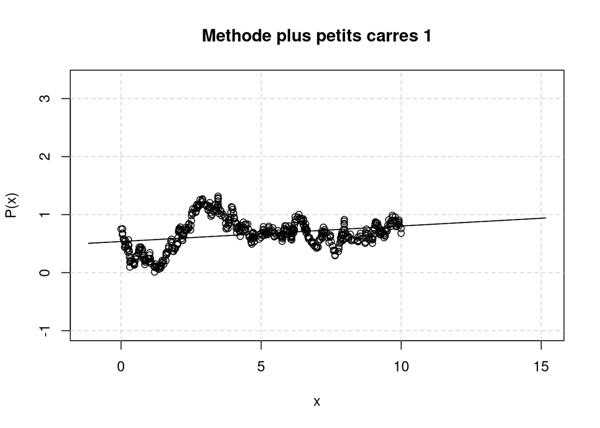

```
## 0.06401521949 + 0.4887713901*x - 0.09688077802*x^2 + 0.005581087641*x^3
```

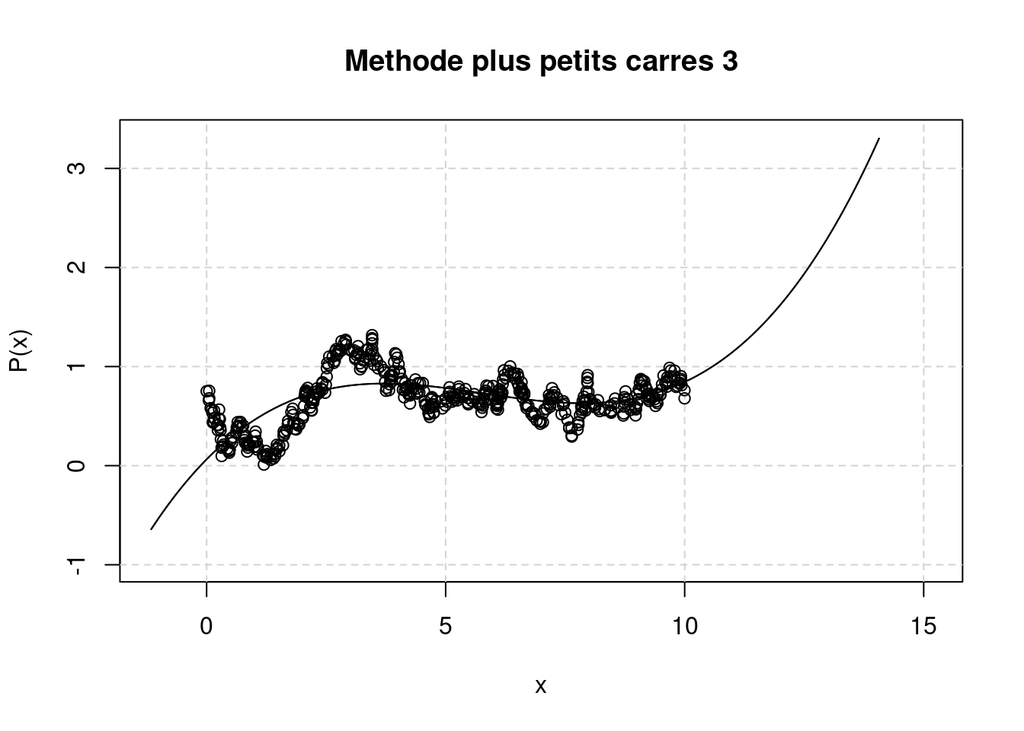

```
## 0.506104844 - 0.7413163983*x + 0.690998709*x^2 - 0.1886417769*x^3 +
## 0.02041895543*x^4 - 0.0007703038056*x^5
```

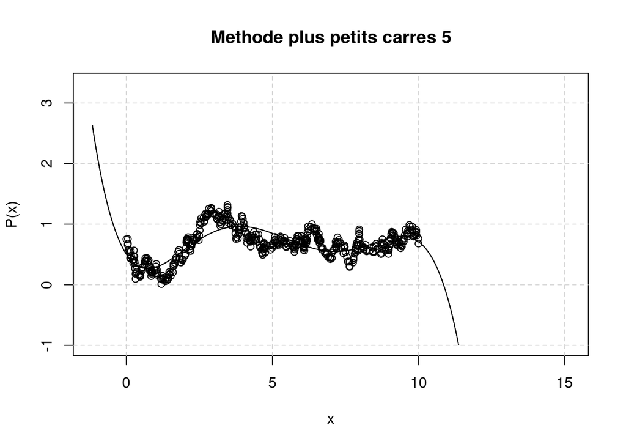

```
## 0.8752178056 - 2.44876996*x + 2.575940503*x^2 - 1.041606293*x^3 +
## 0.2105669838*x^4 - 0.02278168625*x^5 + 0.001260339721*x^6 - 2.792829853e-05*x^7
```

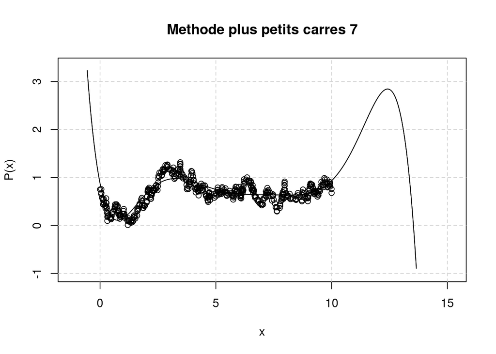

```
## 0.4467136691 + 0.9358902549*x - 4.055478473*x^2 + 4.472969175*x^3 -
## 2.188655297*x^4 + 0.5782461238*x^5 - 0.08859868475*x^6 + 0.007887790898*x^7 -
## 0.0003789513035*x^8 + 7.601445628e-06*x^9
```

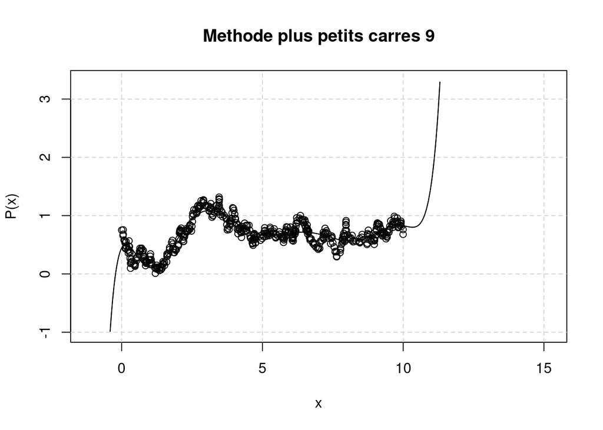

```r
vandermonde <- function(N, xi) {
  N <- N+1
  #On creer la matrice contenant les xi
  res <- matrix(rep(xi, N), ncol = N)
  #On les met a la bonne puissance
  res <- res^(col(res)-1)
  return(res)
}

aux <- function(delta) {
  plot(delta$X, delta$Y)
  degre <- readline(prompt = "Combien de pics voyez vous?")
  return((as.integer(degre) + 1))
}

q3<-function(N, d) {
  m <- vandermonde(N, d$X)
  y0 <- d$Y
  m[m < 10^-6] <- 0
  res <- solve(t(m) %*% m, tol = NULL) %*% t(m) %*% y0
  return(res)
}

delta<-generate(500,0.1,0,10,0,5)
#d<-aux(delta)
#print(d)

for (d in c(1,3,5,7,9)) {
  res <- q3(d, delta)
  print(as.polynomial(res))
  plot(as.polynomial(res), ylim = c(-1,max(delta$Y) +2), xlim = c(-1,15), main = paste("Methode plus petits carres",d))
  points(delta$X, delta$Y)
}
```

**4. Soit le nuage de points suivant à traiter $\Delta = \{(0, 2), (1, 1), (2, 0), (3, -1), (4, -3), (6, -1), (7, 0), (9, 2), (11, 4), (12, 5), (15, 7), (16, 10), (17, 8), (18, -3), (20, -10)\}$**